# PROJECT PART 1

## BOGAZICI UNIVERSITY FALL’19

## IE 423 QUALITY ENGINEERING

## Quality Control on Images

Due Date: 30.10.2019

Instructor: Mustafa Baydogan

Group Members: Sinan Demirhan Abdullah Yildiz Ogulcan Ece Merve Keskin Merve Gülsüm Kiratli

We are a group of Quality Engineers in a linen manufacturer. Linen is a textile made from the fibers of the flax plant. Linen is laborious to manufacture, but the fiber is very absorbent and garments made of linen are valued for their exceptional coolness and freshness in hot weather. Automation of the visual inspection for quality control in production of materials with textures (tiles, textile, leather, etc.) is not widely implemented. A sophisticated system for image acquisition, as well as a fast and efficient procedure for texture analysis is needed for this purpose. As the first part of the project, you choose the inner part of a textile product.

## PROJECT PART 1

### Question 1-)

Read image as a variable in R/Python. For R, you need to install “jpeg” package to read image into avariable. The variable you obtain is an array with three dimensions (suppose you read image to a variable “img”, try running “str(img)” command to see the structure of the variable. The size of the array should be 512 x 512 x 3 for the three dimensions). If you prefer Python, please find the appropriate module for this task.

```r
library(jpeg)
getwd()
```

```
## [1] "C:/Users/Sinan/Desktop"
```

```r
setwd("C:/Users/Sinan/Desktop")
img<-readJPEG("surfacenew.jpg")
str(img)
```

```
##  num [1:512, 1:512, 1:3] 0.416 0.325 0.435 0.38 0.443 ...
```

### Question 2-)

What is the structure of the variable that stores the image? What is the dimension?

```r
dim(img)
```

```
## [1] 512 512   3
```

Structure of the variable that stores the image is large array. The size of the array is 512 x 512 x 3 for the three dimensions.

1. Display the image.

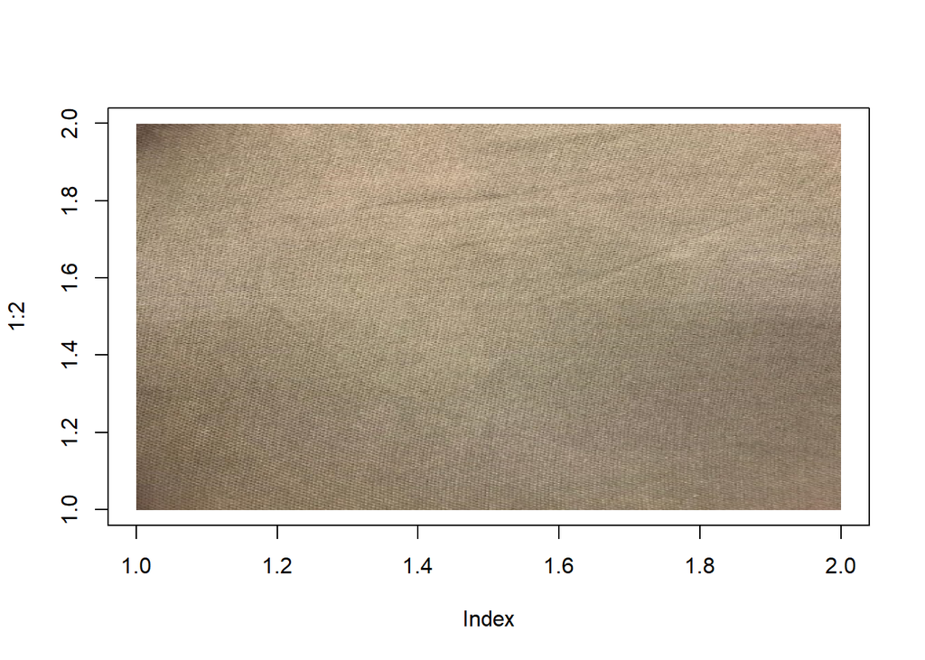

```r
#a-)
plot(1:2, type='n')
rasterImage(img, 1, 1, 2, 2)
```

2. Display each channel using “image” function on a single plot.

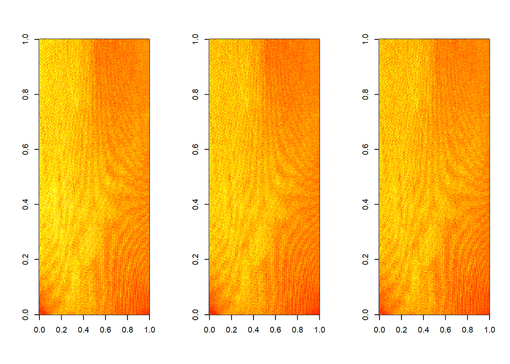

```r
R_channel<-matrix(img[ , , 1], 512, 512)
G_channel<-matrix(img[ , , 2], 512, 512)
B_channel<-matrix(img[ , , 3], 512, 512)

par(mfrow = c(1,3))
image(R_channel)
image(G_channel)
image(B_channel)
```

### Question 3-)

For each channel, take the average of the columns and plot the average as a line plot for each channel on a single plot.

```r
avr_red<-(colSums(R_channel))/512
avr_green<-(colSums(G_channel))/512
avr_blue<-(colSums(B_channel))/512
```

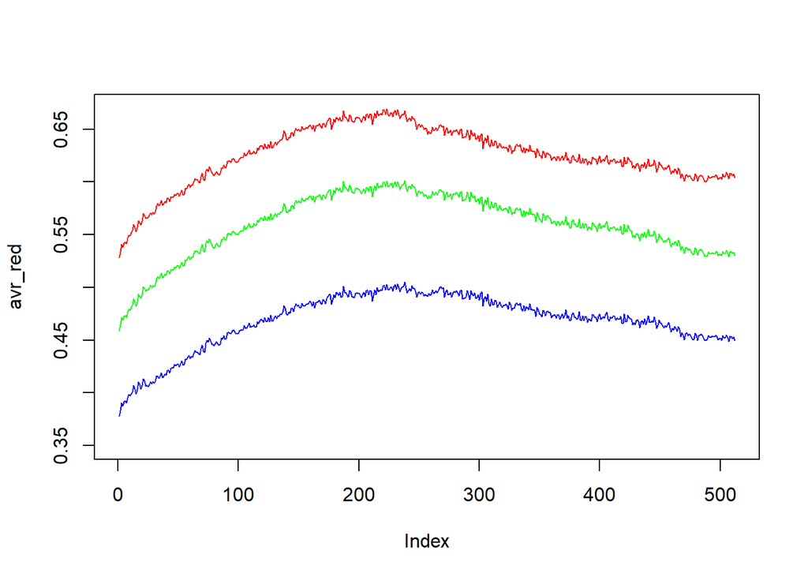

```r
plot(avr_red, type="l", col="red",ylim = range(0.35,0.67))
lines(avr_green, col="green")
lines(avr_blue, col="blue")
```

### Question 4-)

For each channel, subtract one half of the image from the other half (choice of halves is up to you but cropping the image vertically/horizontally into two parts make more sense) and display the new image.

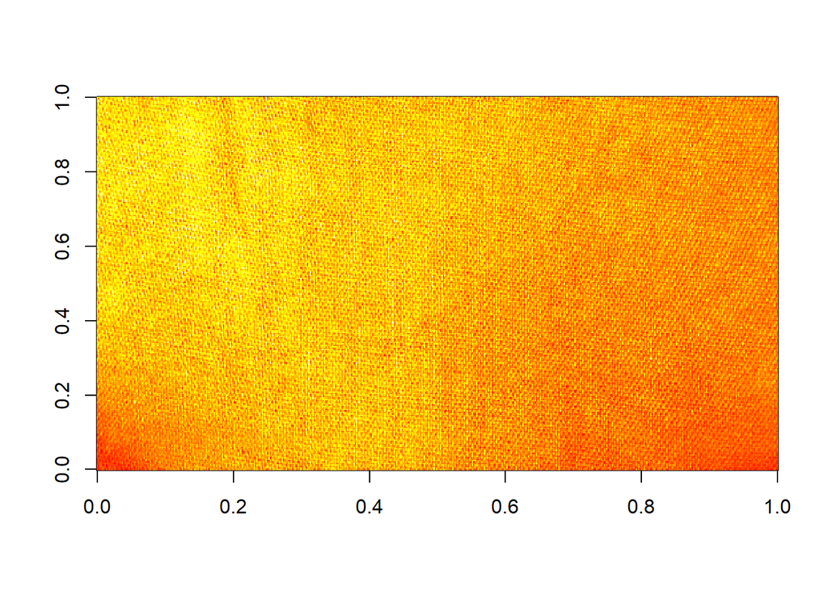

```r
halfred<-R_channel[ ,1:256]
half2red<-R_channel[ ,512:257]
image(halfred)
```

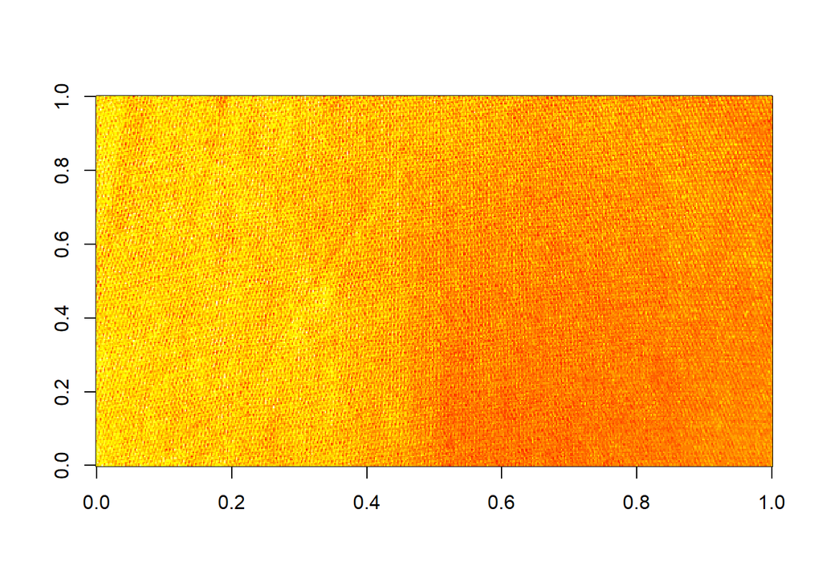

```r
image(half2red)
```

```r
red_new<-abs(halfred-half2red)
```

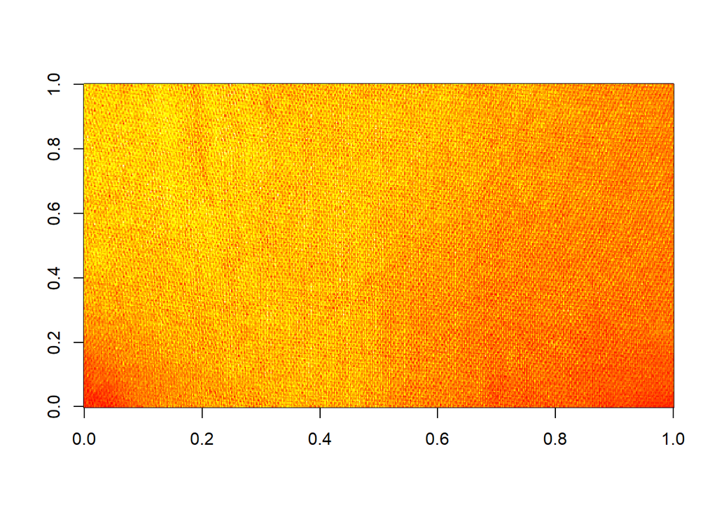

```r
halfgreen<-G_channel[ ,1:256]
half2green<-G_channel[ ,512:257]
image(halfgreen)
```

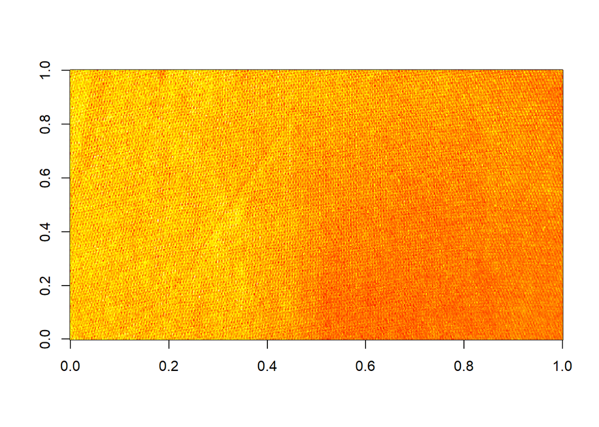

```r
image(half2green)
```

```r
green_new<-abs(halfgreen-half2green)
```

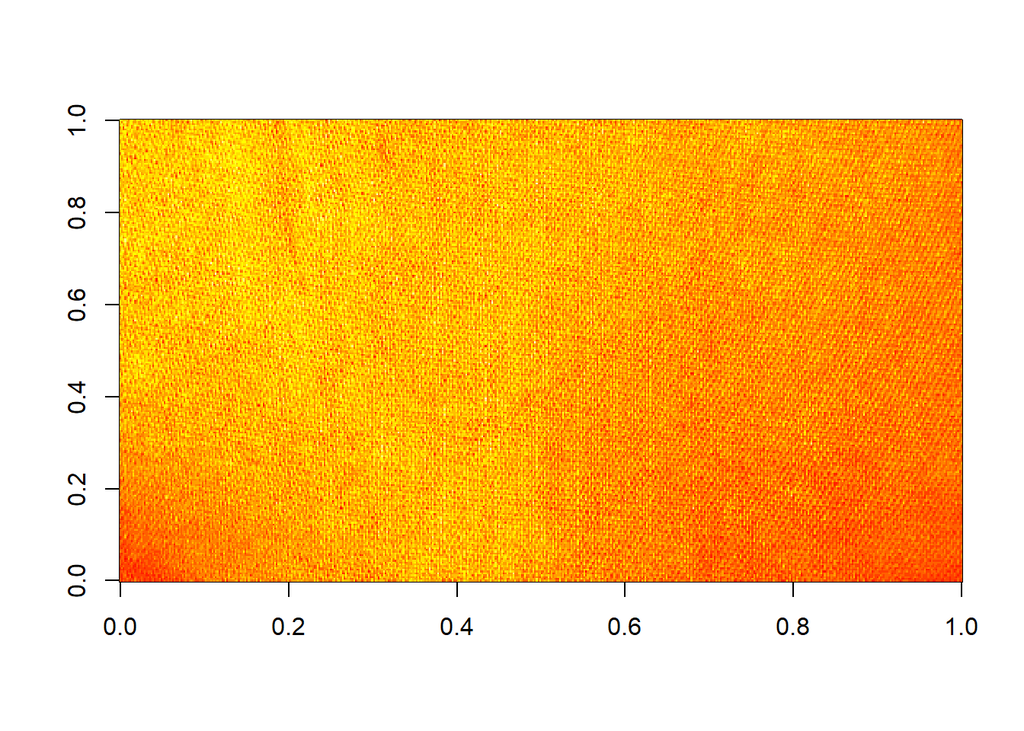

```r
halfblue<-B_channel[ ,1:256]
half2blue<-B_channel[ ,512:257]
image(halfblue)
```

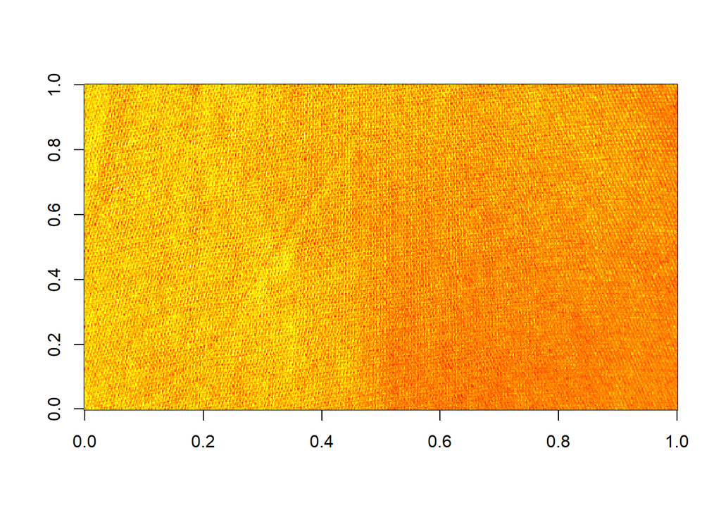

```r
image(half2blue)
```

```r
blue_new<-abs(halfblue-half2blue)
```

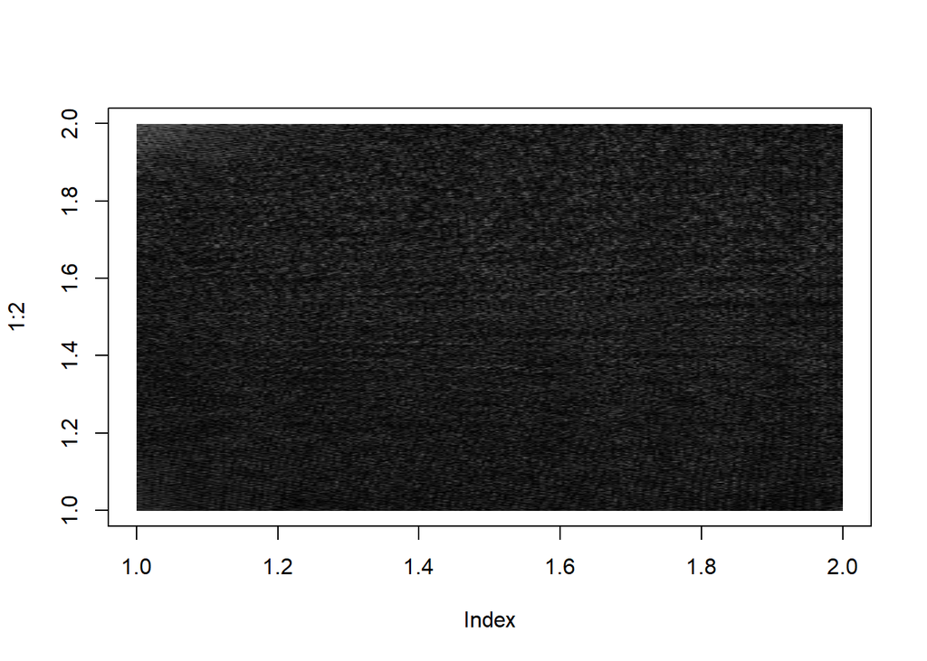

```r
newimg<-img[1:512,257:512,1:3]
newimg<-red_new
newimg<-green_new
newimg<-blue_new
plot(1:2, type='n')
rasterImage(newimg, 1, 1, 2, 2)
```

### Question 5-)

Apply median filtering to each channel of the image with the following window sizes, display the images (as a color image like in part 2-a) and discuss about the effect of window size based on your observations: a) 5x5

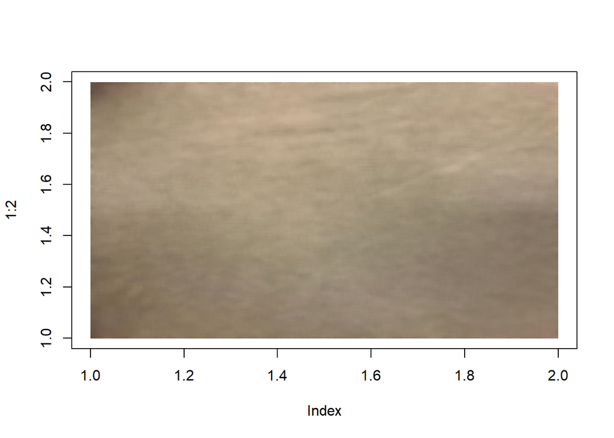

```r
library("EBImage")

median_5<-medianFilter(img,5)
plot(1:2, type='n')
rasterImage(median_5, 1, 1, 2, 2)
```

2. 11x11

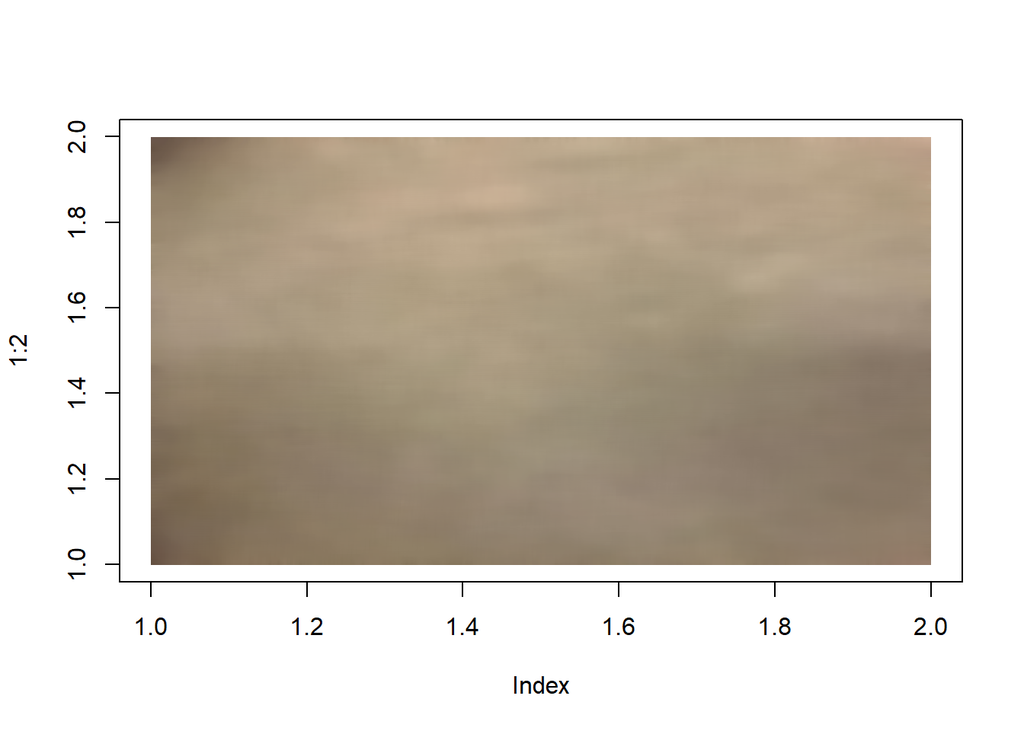

```r
median_11<-medianFilter(img,11)
plot(1:2, type='n')
rasterImage(median_11, 1, 1, 2, 2)
```

3. 31x31

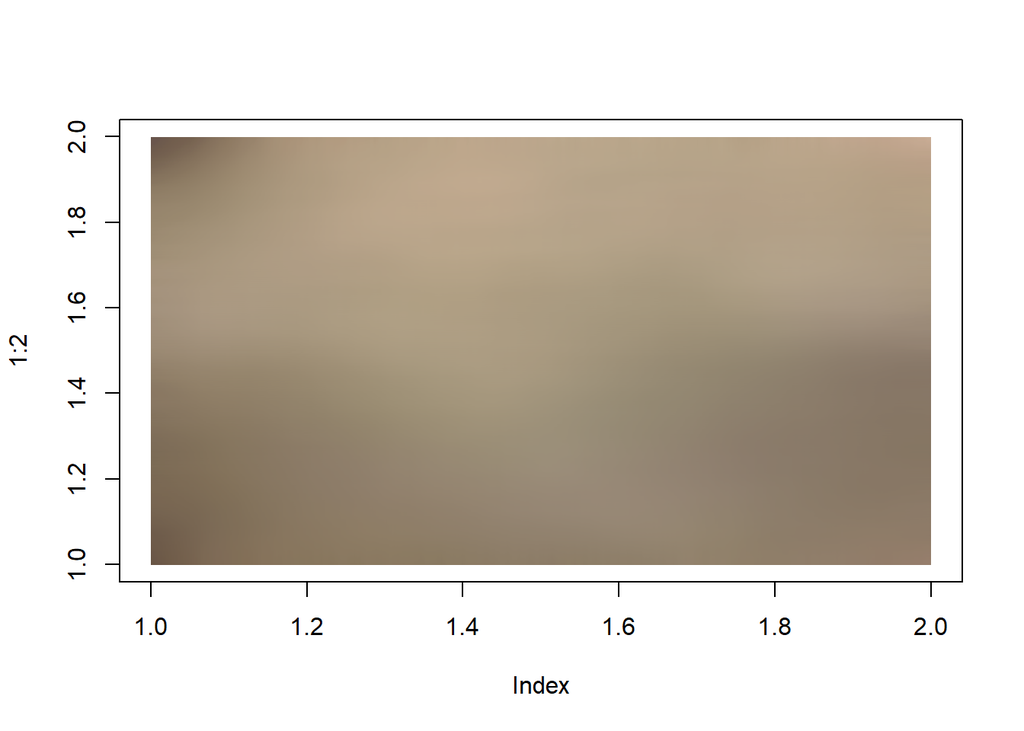

```r
median_31<-medianFilter(img,31)

plot(1:2, type='n')
rasterImage(median_31, 1, 1, 2, 2)
```

Our answer for this question evaluates the performance of median filter based on the effective median per window by using different window sizes. As a conclusion, low level window size such as 5x5 gives better performance in low noise densities and higher window size causes a degree of blurring effect to filtered noise. Because, In a k×k window, if the number of polluted pixels is very large, then the median computed will be an impulse and the noise will not be removed.